# covid19 analytics

### Library

```r
library(tidyverse)
library(ggplot2)
library(lubridate)
```

### 1. patient 데이터셋 정보

- id: 확진자의 id (n번째 확진자)
- sex: 성별
- birth_year: 출생 연도
- country: 국적
- Korea: 대한민국
- China: 중국
- Mongolia: 몽골
- region: 주 활동 지역 (광역시/도 단위)
- capital area: 수도권 (서울특별시/인천광역시/경기도)
- filtered at airport: 공항 검역 이후 활동하지 않은 경우
- Busan: 부산광역시
- Daegu: 대구광역시
- Daejeon: 대전광역시
- Gwangju: 광주광역시
- Ulsan: 울산광역시
- Gangwon-do: 강원도
- Chungcheongbuk-do: 충청북도
- Chungcheongnam-do: 충청남도
- Jeollabuk-do: 전라북도
- Jeollanam-do: 전라남도
- Gyeongsangbuk-do: 경상북도
- Gyeongsangnam-do: 경상남도
- Jeju-do: 제주도
- group: 특정 집단 관련
- Shincheonji Church: 신천지 관련
- Cheongdo Daenam Hospital: 청도대남병원 관련
- Eunpyeong St. Mary’s Hospital: 은평성모병원 관련
- Onchun Church: 온천 교회 관련
- Myungsung Church: 명성 교회 관련
- Pilgrimage: 이스라엘 성지순례 관련
- infection_reason: 감염 경로
- visit to ooo: 감염 위험 나라/도시 방문
- contact with patient: 국내 확진자와 접촉
- contact with patient in ooo: 해외 확진자와 접촉
- residence in Wuhan: 중국 우한 거주
- pilgrimage to Israel: 이스라엘 성지순례
- infection_order: 감염 차수 (n차 감염)
- infected_by: 해당 확진자의 감염원 id
- contact_number: 접촉자 수
- confirmed_date: 확진 일자
- released_date: 퇴원 일자 (격리 해제 일자)
- deceased_date: 사망 일자
- state: 상태
- isolated: 입원 (격리)
- released: 퇴원 (격리 해제)
- deceased: 사망

### 2. route 데이터셋 정보

- id: 확진자의 id (n번째 확진자)
- date: 일자
- province: 특별시/광역시/도
- city: 시/군/구
- visit: 방문한 장소 (종류)
- airport: 공항
- hospital_isolated: 격리된 병원
- hospital: 대형급 병원 또는 보건소
- clinic: 의원급 병원
- hotel: 호텔
- store: 소형 가게
- market: 대형 마트
- restaurant: 식당
- cafe: 카페
- house: 집
- bus_terminal: 버스 터미널
- train_station: 기차역
- movie_theater: 영화관
- hair_salon: 미용실
- church: 교회
- etc: 기타 방문 장소
- latitude: 위도
- longitude: 경도

### 3. time 데이터셋 정보

- date: 일자
- acc_test: 누적 검사 수 (진행 중인 검사 포함)
- acc_negative: 누적 음성 결과 수
- acc_confirmed: 누적 양성 결과 수 (확진)
- acc_released: 누적 격리 해제 수
- acc_deceased: 누적 사망 수
- new_test: 신규 검사 수
- new_negative: 신규 음성 결과 수
- new_confirmed: 신규 양성 결과 수 (확진)
- new_released: 신규 격리 해제 수
- new_deceased: 사망 수

### Data Loading

```r
patient <- read.csv("patient.csv", na.strings = c("", "NA", " "))
route <- read.csv("route.csv", na.strings = c("", "NA", " "))
time <- read.csv("time.csv", na.strings = c("", "NA", " "))

dim(patient)
```

```
## [1] 6285   14
```

```r
str(patient)
```

```
## 'data.frame':    6285 obs. of  14 variables:
##  $ id              : int  1 2 3 4 5 6 7 8 9 10 ...
##  $ sex             : Factor w/ 2 levels "female","male": 1 2 2 2 2 2 2 1 1 1 ...
##  $ birth_year      : int  1984 1964 1966 1964 1987 1964 1991 1957 1992 1966 ...
##  $ country         : Factor w/ 3 levels "China","Korea",..: 1 2 2 2 2 2 2 2 2 2 ...
##  $ region          : Factor w/ 14 levels "Busan","capital area",..: 7 7 2 2 2 2 2 12 2 2 ...
##  $ group           : Factor w/ 6 levels "Cheongdo Daenam Hospital",..: NA NA NA NA NA NA NA NA NA NA ...
##  $ infection_reason: Factor w/ 15 levels " visit to China",..: 15 15 15 15 15 2 15 15 2 2 ...
##  $ infection_order : int  1 1 1 1 1 2 1 1 2 3 ...
##  $ infected_by     : int  NA NA NA NA NA 3 NA NA 5 6 ...
##  $ contact_number  : int  45 75 16 95 31 17 9 113 2 43 ...
##  $ confirmed_date  : Factor w/ 31 levels "2020-01-20","2020-01-24",..: 1 2 3 4 5 5 5 6 6 6 ...
##  $ released_date   : Factor w/ 19 levels "2020-02-05","2020-02-06",..: 2 1 5 3 17 9 6 5 11 9 ...
##  $ deceased_date   : Factor w/ 12 levels "2020-02-19","2020-02-21",..: NA NA NA NA NA NA NA NA NA NA ...
##  $ state           : Factor w/ 3 levels "deceased","isolated",..: 3 3 3 3 3 3 3 3 3 3 ...
```

```r
dim(route)
```

```
## [1] 102   7
```

```r
str(route)
```

```
## 'data.frame':    102 obs. of  7 variables:
##  $ id       : int  1 1 2 2 3 3 3 3 3 3 ...
##  $ date     : Factor w/ 19 levels "2020-01-19","2020-01-20",..: 1 2 4 5 2 4 4 5 5 6 ...
##  $ province : Factor w/ 8 levels "Daegu","Gangwon-do",..: 5 5 4 8 5 8 8 8 8 4 ...
##  $ city     : Factor w/ 27 levels "Bucheon-si","Buk-gu",..: 14 18 6 14 14 4 4 4 4 7 ...
##  $ visit    : Factor w/ 17 levels "airport","bus_terminal",..: 1 10 1 10 1 5 11 16 15 15 ...
##  $ latitude : num  37.5 37.5 37.6 37.6 37.5 ...
##  $ longitude: num  126 127 127 127 126 ...
```

```r
dim(time)
```

```
## [1] 46 11
```

```r
str(time)
```

```
## 'data.frame':    46 obs. of  11 variables:
##  $ X176         : Factor w/ 46 levels "2020-01-20","2020-01-21",..: 1 2 3 4 5 6 7 8 9 10 ...
##  $ acc_test     : int  1 1 4 22 27 27 51 61 116 187 ...
##  $ acc_negative : int  0 0 3 21 25 25 47 56 97 155 ...
##  $ acc_confirmed: int  1 1 1 1 2 2 3 4 4 4 ...
##  $ acc_released : int  0 0 0 0 0 0 0 0 0 0 ...
##  $ acc_deceased : int  0 0 0 0 0 0 0 0 0 0 ...
##  $ new_test     : int  1 0 3 18 5 0 24 10 55 71 ...
##  $ new_negative : int  0 0 3 18 4 0 22 9 41 58 ...
##  $ new_confirmed: int  1 0 0 0 1 0 1 1 0 0 ...
##  $ new_released : int  0 0 0 0 0 0 0 0 0 0 ...
##  $ new_deceased : int  0 0 0 0 0 0 0 0 0 0 ...
```

### Missing value Check

```r
## Patient Data
colSums(is.na(patient))
```

```
##               id              sex       birth_year          country
##                1             5864             5877                2
##           region            group infection_reason  infection_order
##             5876             6202             6139             6250
##      infected_by   contact_number   confirmed_date    released_date
##             6215             6235                1             6247
##    deceased_date            state
##             6262                1
```

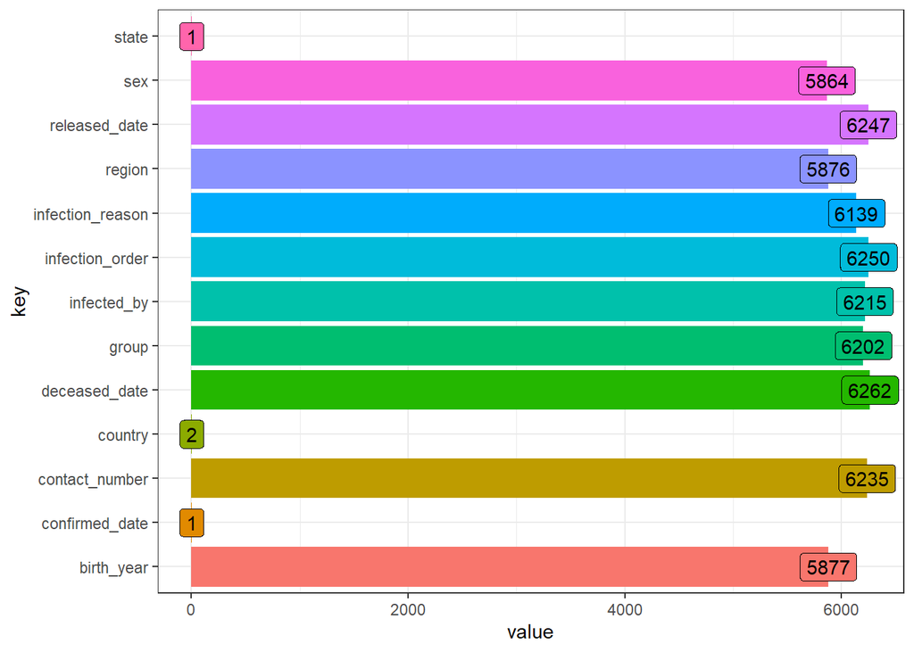

```r
patient %>%
  select(-id) %>%
  summarise_all(funs(sum(is.na(.)))) %>%
  gather() %>%
  filter(value > 0) %>%
  ggplot(aes(key, value, fill = as.factor(key))) +
  geom_bar(stat = "identity") +
  geom_label(aes(label = value)) +
  theme_bw() +
  theme(legend.position = "none") +
  coord_flip()
```

```r
## Route Data
colSums(is.na(route))
```

```
##        id      date  province      city     visit  latitude longitude
##         0         0         0         0         0         0         0
```

```r
## Time Data
colSums(is.na(time))
```

```
##          X176      acc_test  acc_negative acc_confirmed  acc_released
##             0             0             0             0             0
##  acc_deceased      new_test  new_negative new_confirmed  new_released
##             0             0             0             0             0
##  new_deceased
##             0
```